# Ejemplo de solución ejercicio prático N°5

ANOVA para muestras independientes

## Enunciado

Un equipo de investigación del área de interacción humano-información está estudiando si el área temática y el nivel de dificultad del problema de información influyen en el tiempo (en segundos) que le toma a una persona en formular una consulta de búsqueda para resolver dicho problema. Para ello, han reclutado a un grupo voluntario de participantes, asignados aleatoriamente a distintos grupos. Cada participante debe resolver tres problemas de información con diferentes niveles de dificultad: baja, media y alta. A su vez, cada grupo debe resolver problemas relacionados a una temática diferente. Los datos recolectados contemplan las siguientes variables:

| Variable | Descripción |
| --- | --- |
| id | Identificador único de cada participante. |
| area | Área temática de los problemas que el participante debe responder. Variable categórica con los niveles Arquitectura, Biología, Computación, Economía, Física, Leyes, Literatura, Matemáticas, Música, Pe… |
| dificultad | Nivel de dificultad del problema resuelto. Variable categórica con los niveles Baja, Media y Alta. |
| tiempo | Tiempo, en segundos, que toma al participante formular la consulta |

En este momento, equipo de investigación busca determinar si existen diferencias en el tiempo que tardan las personas en formular una consulta para un problema fácil en las áreas de física, química y biología.

En esta pregunta se pide inferir acerca de medias de una variable numérica de tres muestras independientes. Luego se requiere usar un **procedimiento ANOVA** para este tipo de muestras.

Las hipótesis serían:

H$_0$: los tiempos promedio requeridos para formular una consulta asociada a un problema de información de baja dificultad para las áreas de física ($\small \mu_{F}$), química ($\small \mu_{Q}$) y biología ($\small \mu_{B}$) son iguales ($\small \mu_{F}=\mu_{Q}=\mu_{B}$).

H$_A$: el tiempo requerido para formular la consulta asociada a un problema de información de baja dificultad es diferente para al menos una de las áreas ($\small\exists i, j \in \{B, F, Q\}: \mu_{i}\neq\mu_{j}$).

Obtengamos la muestra de datos que debemos utilizar.

```r
src_dir <- "~/Downloads"
src_basename <- "EP05 Datos.csv"
src_file <- file.path(src_dir, src_basename)
print(src_file)
```

```
## [1] "~/Downloads/EP05 Datos.csv"
```

```r
datos <- read.csv(file = src_file, stringsAsFactors = TRUE)

# Seleccionamos datos de interés
datos_largos <- datos %>%
  filter(dificultad == "Baja") %>%
  filter(area == "Física" | area == "Química" | area == "Biología") %>%
  select(id, area, tiempo) %>%
  droplevels()
datos_largos[["id"]] <- factor(datos_largos[["id"]])
```

Ahora verifiquemos las condiciones para asegurar que podemos aplicar el procedimiento con validez.

La variable dependiente corresponde a tiempo, que sabemos tiene escala de razón, y por lo tanto una escala continua de intervalos iguales, por ser una medida física.

Por otro lado, el enunciado indica que las observaciones son independientes entre sí, pues provienen de personas diferentes que fueron asignadas a cada grupo de manera aleatoria.

Revisemos ahora la condición de normalidad por medio de un gráfico Q-Q.

```r
library(ggpubr)
```

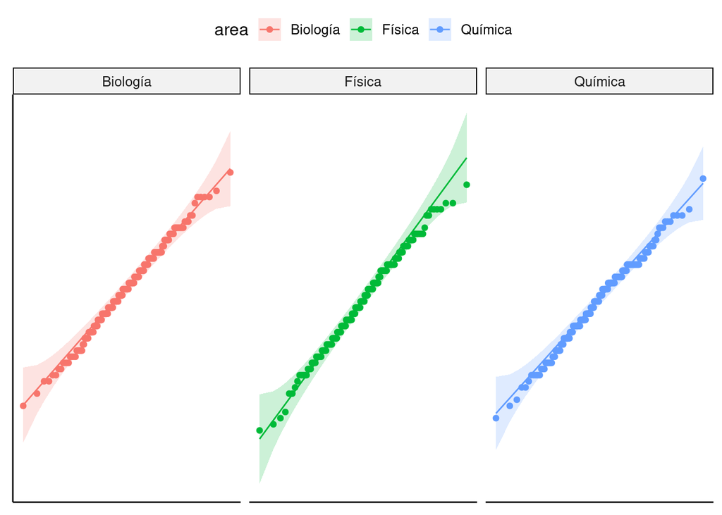

```r
g <- ggqqplot(datos_largos,
              x = "tiempo",
              y = "area",
              color = "area")

g <- g + facet_wrap(~ area)
g <- g + rremove("x.ticks") + rremove("x.text")
g <- g + rremove("y.ticks") + rremove("y.text")
g <- g + rremove("axis.title")
print(g)
```

El gráfico generado muestra que la distribución de los datos de cada una de las muestras puede considerarse cercana a la normal pues, si bien no forman una recta, todos se encuentran dentro de la región aceptable del gráfico Q-Q y no se observan comportamientos extraños no aleatorios.

En cuanto a la condición de homocedasticidad, se posterga su discusión hasta ver el resultado de la prueba de Levene efectuada por `ezAnova()`.

Puesto que hasta ahora no tenemos motivos que indiquen que los datos podrían incumplir alguna de las condiciones, podemos proceder con el procedimiento ANOVA para muestras independientes considerando un nivel de significación de 0,05.

```r
library(ez)

alfa <- 0.05

omnibus <- ezANOVA(
  data = datos_largos,
  dv = tiempo,
  between = area,
  wid = id,
  return_aov = TRUE
)
```

```
## Coefficient covariances computed by hccm()
```

```r
print(omnibus)
```

```
## $ANOVA
##   Effect DFn DFd        F           p p<.05        ges
## 1   area   2 597 4.687319 0.009553026     * 0.01546014
##
## $`Levene's Test for Homogeneity of Variance`
##   DFn DFd   SSn      SSd        F         p p<.05
## 1   2 597 43.96 10994.38 1.193524 0.3038733
##
## $aov
## Call:
##    aov(formula = formula(aov_formula), data = data)
##
## Terms:
##                      area Residuals
## Sum of Squares    489.053 31144.120
## Deg. of Freedom         2       597
##
## Residual standard error: 7.222721
## Estimated effects may be unbalanced
```

```r
print(summary(omnibus[["aov"]]))
```

```
##              Df Sum Sq Mean Sq F value  Pr(>F)
## area          2    489  244.53   4.687 0.00955 **
## Residuals   597  31144   52.17
## ---
## Signif. codes:  0 '***' 0.001 '**' 0.01 '*' 0.05 '.' 0.1 ' ' 1
```

Podemos ver que la prueba de homocedasticidad de Levene resulta no significativa con 95% de confianza ($\small F(2,597)=1{,}194; p=0{,}304$), por lo que se falla en rechazar la hipótesis nula de esta prueba, por lo que debemos concluir que **no hay suficiente evidencia estadística para descartar** que se cumple la condición de homocedasticidad en estos datos.

Interpretemos este resultado ómnibus.

El procedimiento ANOVA resultó significativo ($\small F(2,597)=4{,}687; p=0{,}010$). En consecuencia, con 95% de confianza, rechazamos la hipótesis nula en favor de la hipótesis alternativa y concluimos que se requiere una cantidad de tiempo diferente para formular las consultas asociadas a un problema de información de dificultad baja para al menos una de las tres áreas (física, química y biología).

Puesto que el procedimiento ómnibus encuentra diferencias estadísticamente significativas, es necesario realizar un procedimiento post-hoc. Puesto que no requerimos hacer contrastes adicionales, usaremos la prueba HSD de Tukey, más poderosa que los factores de corrección no paramétricos (como Bonferroni y Holm), ya que no se ha descartado que los datos siguen distribuciones normales y con igual varianza.

```r
post_hoc <- TukeyHSD(omnibus[["aov"]], which = "area", ordered = TRUE,
                     conf.level = 1 - alfa)
print(post_hoc)
```

```
##   Tukey multiple comparisons of means
##     95% family-wise confidence level
##     factor levels have been ordered
##
## Fit: aov(formula = formula(aov_formula), data = data)
##
## $area
##                  diff        lwr      upr     p adj
## Química-Física   0.03 -1.6670294 1.727029 0.9990493
## Biología-Física  1.93  0.2329706 3.627029 0.0211077
## Biología-Química 1.90  0.2029706 3.597029 0.0237243
```

Podemos ver una representación gráfica del efecto encontrado en este análisis (producido en la variable dependiente `tiempo` por la variable independiente `area`).

```r
efecto <- ezPlot(data = datos_largos, dv = tiempo, wid = id,
                 between = area, x = area,
                 y_lab = " Tiempo requerido para formular consultas [s]")
```

```
## Coefficient covariances computed by hccm()
```

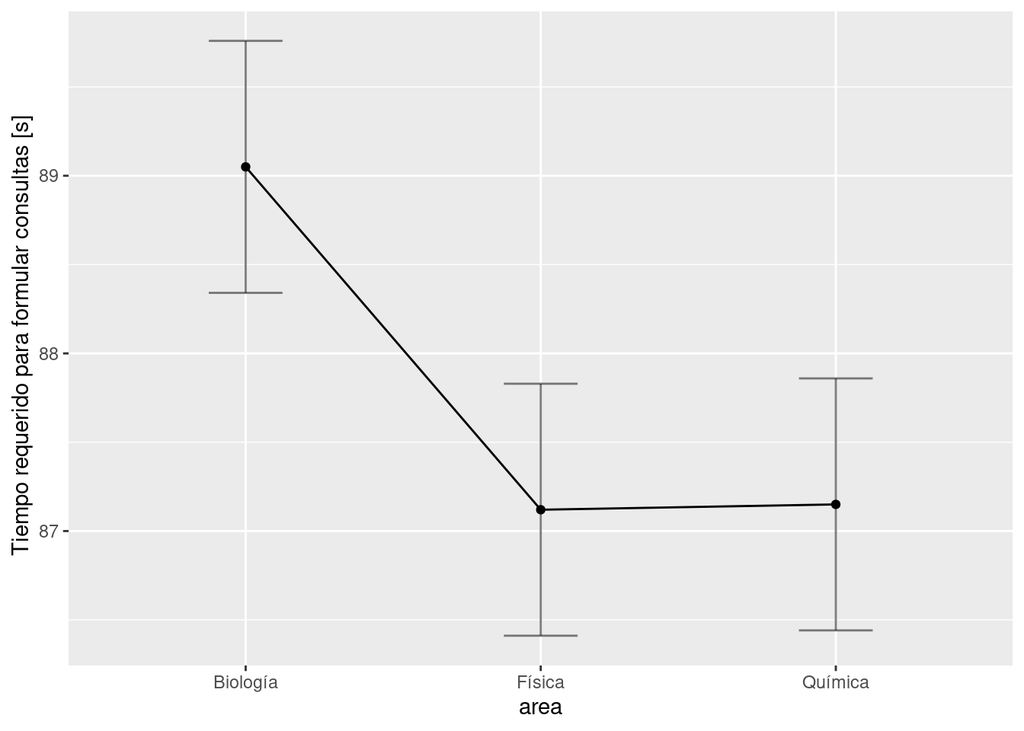

```r
print(efecto)
```

Vemos que el gráfico del efecto coincide con los resultados de la prueba post-hoc, mostrando con claridad que las personas que resuelven un problema de información sencillo en el área de biología requieren alrededor de dos segundos más para formular la consulta que sus pares en las áreas de física y química. Redactemos una conclusión.

El análisis post-hoc usando el método de la diferencia honestamente significativa de Tukey indica que existen diferencias significativas en los pares biología-química $(\small D_{(B-Q)}=1{,}90; 95\%\; \text{CI} = [0{,}203; 3{,}597]; p=0{,}024)$ y biología-física $(\small D_{(B-F)}=1{,}93; 95\%\; \text{CI} = [0{,}233; 3{,}627]; p=0{,}021)$. En consecuencia, podemos concluir con 95% de confianza que se requiere una cantidad de tiempo mayor para formular una consulta asociada a un problema de información de baja dificultad en el área de biología que en las áreas de física y química.